# PA1_template

Brayam Pineda

## Objective

This file contain the solve to the first project of the Reproducible Research course in Coursera offered by Johns Hopkins University.For it we will to analyze the activity dataset that you can find in [Activity monitoring data](https://d396qusza40orc.cloudfront.net/repdata%2Fdata%2Factivity.zip)

In short, we need to complete five general assignments, they are:

- Loading and preprocessing the data
- What is mean total number of steps taken per day?
- What is the average daily activity pattern?
- Imputing missing values
- Are there differences in activity patterns between weekdays and weekends?

So let’s go

## 1. Loading and preprocessing the data

```r
data <- read.csv("activity.csv")
head(data)
```

```
##   steps       date interval
## 1    NA 2012-10-01        0
## 2    NA 2012-10-01        5
## 3    NA 2012-10-01       10
## 4    NA 2012-10-01       15
## 5    NA 2012-10-01       20
## 6    NA 2012-10-01       25
```

That is not too informative, so we are going to use the *str()* function

```r
str(data)
```

```
## 'data.frame':    17568 obs. of  3 variables:
##  $ steps   : int  NA NA NA NA NA NA NA NA NA NA ...
##  $ date    : chr  "2012-10-01" "2012-10-01" "2012-10-01" "2012-10-01" ...
##  $ interval: int  0 5 10 15 20 25 30 35 40 45 ...
```

We can see that the class of the columns is not the best, so we are going to solve this

```r
data$steps <- as.numeric(data$steps)
data$date <- as.Date(data$date)
data$interval <- as.numeric(data$interval)
str(data)
```

```
## 'data.frame':    17568 obs. of  3 variables:
##  $ steps   : num  NA NA NA NA NA NA NA NA NA NA ...
##  $ date    : Date, format: "2012-10-01" "2012-10-01" ...
##  $ interval: num  0 5 10 15 20 25 30 35 40 45 ...
```

Is a good practice explore a little more the data before start with the analyze, a good way is through the *summary()* function

```r
summary(data)
```

```
##      steps             date               interval
##  Min.   :  0.00   Min.   :2012-10-01   Min.   :   0.0
##  1st Qu.:  0.00   1st Qu.:2012-10-16   1st Qu.: 588.8
##  Median :  0.00   Median :2012-10-31   Median :1177.5
##  Mean   : 37.38   Mean   :2012-10-31   Mean   :1177.5
##  3rd Qu.: 12.00   3rd Qu.:2012-11-15   3rd Qu.:1766.2
##  Max.   :806.00   Max.   :2012-11-30   Max.   :2355.0
##  NA's   :2304
```

## 2. What is mean total number of steps taken per day?

First we need to transform the data base

```r
library(dplyr)
data_v2 <- data %>% group_by(date) %>% summarise(Day = sum(steps, na.rm = FALSE))
data_v2 <- data_v2[!is.na(data_v2$Day), ]
head(data_v2)
```

```
## # A tibble: 6 x 2
##   date         Day
##   <date>     <dbl>
## 1 2012-10-02   126
## 2 2012-10-03 11352
## 3 2012-10-04 12116
## 4 2012-10-05 13294
## 5 2012-10-06 15420
## 6 2012-10-07 11015
```

After that, we can do a histogram to see how the data is behavior

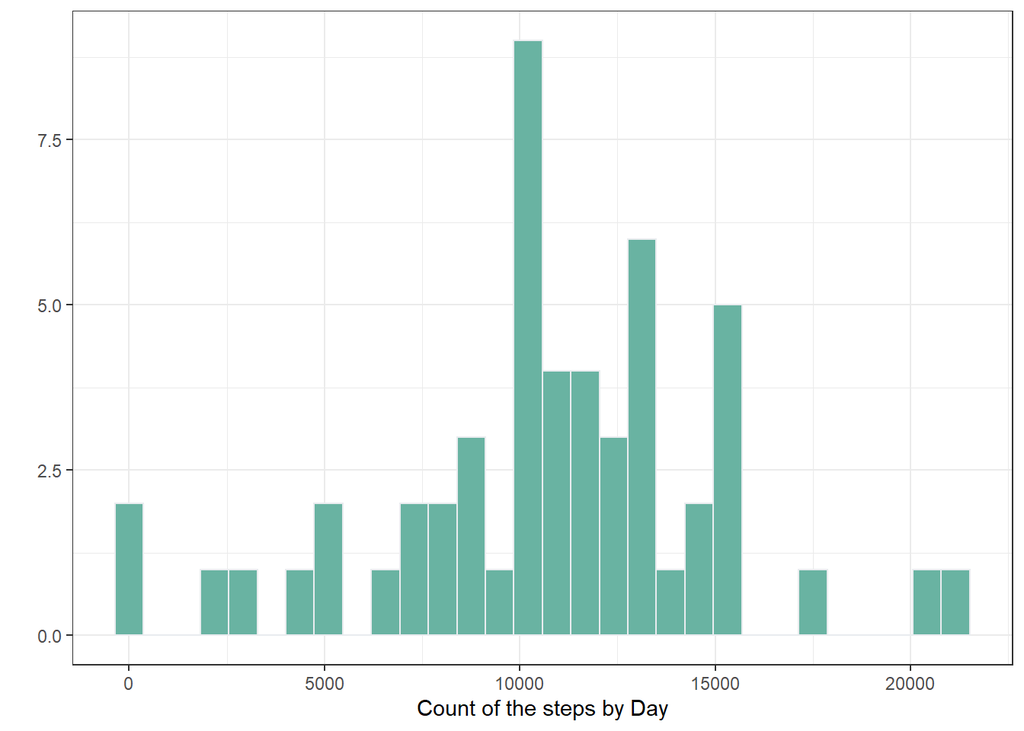

```r
library(ggplot2)
ggplot(data = data_v2, aes(x = Day)) + geom_histogram(color="#e9ecef", fill="#69b3a2") +
  theme_bw() + xlab("Count of the steps by Day") + ylab("")
```

By last, the task request us for calculate the *median* and *mean* of the total of steps, the easiest way is by the *summary* function and we can to report that result in a table

```r
summary(data_v2$Day)
```

```
##    Min. 1st Qu.  Median    Mean 3rd Qu.    Max.
##      41    8841   10765   10766   13294   21194
```

## 3. What is the average daily activity pattern?

- Make a time series plot (i.e. type = “l”) of the 5-minute interval (x-axis) and the average number of steps taken, averaged across all days (y-axis)

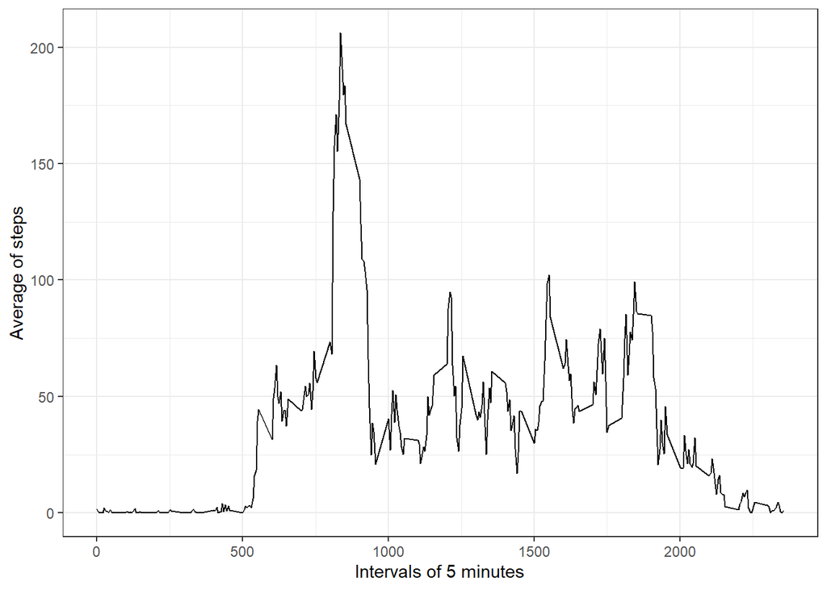

```r
data_v3 <- data %>% group_by(interval) %>% summarise("Average of steps" = mean(steps, na.rm = TRUE))
ggplot(data = data_v3, aes(x = interval, y = `Average of steps`)) +
  geom_line() + theme_bw() +
  xlab("Intervals of 5 minutes")
```

- Which 5-minute interval, on average across all the days in the dataset, contains the maximum number of steps?

```r
max <- data_v3 %>% filter(`Average of steps` == max(`Average of steps`))
knitr::kable(max, caption = ""
       , align = c('c')
       , col.names = c("Interval", "Average of steps")
       , row.names = FALSE
       , justify = 'lcrrcl')
```

| Interval | Average of steps |
| --- | --- |
| 835 | 206.1698 |

In graphic it will be

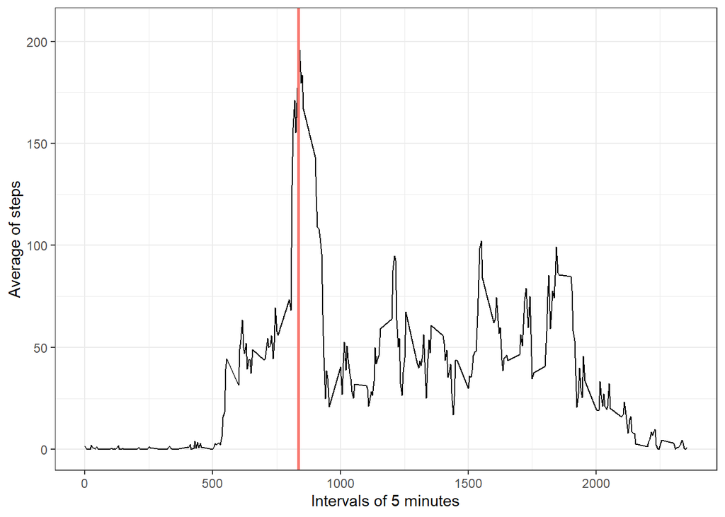

```r
ggplot(data = data_v3, aes(x = interval, y = `Average of steps`)) +
  geom_line() + theme_bw() + geom_vline(aes(xintercept = 835, colour = "red"), size = 1, show.legend = FALSE) +
  xlab("Intervals of 5 minutes")
```

## 4. Imputing missing values

- Calculate and report the total number of missing values in the dataset (i.e. the total number of rows with NAs)

```r
sum(is.na(data$steps))
```

```
## [1] 2304
```

- Devise a strategy for filling in all of the missing values in the dataset.

```r
library(mice)
data_v4 <- data
imputed_data1 <- mice(data_v4)
complete_data1 <- mice::complete(imputed_data1)
```

- Make a histogram of the total number of steps taken each day and Calculate and report the mean and median total number of steps taken per day. Do these values differ from the estimates from the first part of the assignment? What is the impact of imputing missing data on the estimates of the total daily number of steps?

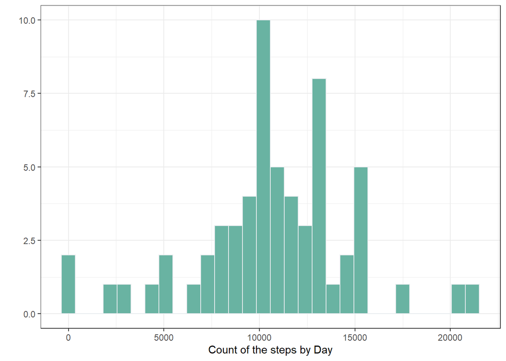

```r
complete_data2 <- complete_data1 %>% group_by(date) %>% summarise(Steps = sum(steps, na.rm = TRUE))
ggplot(data = complete_data2, aes(x = Steps)) + geom_histogram(color="#e9ecef", fill="#69b3a2") +
  theme_bw() + xlab("Count of the steps by Day") + ylab("")
```

Recall the other graphic

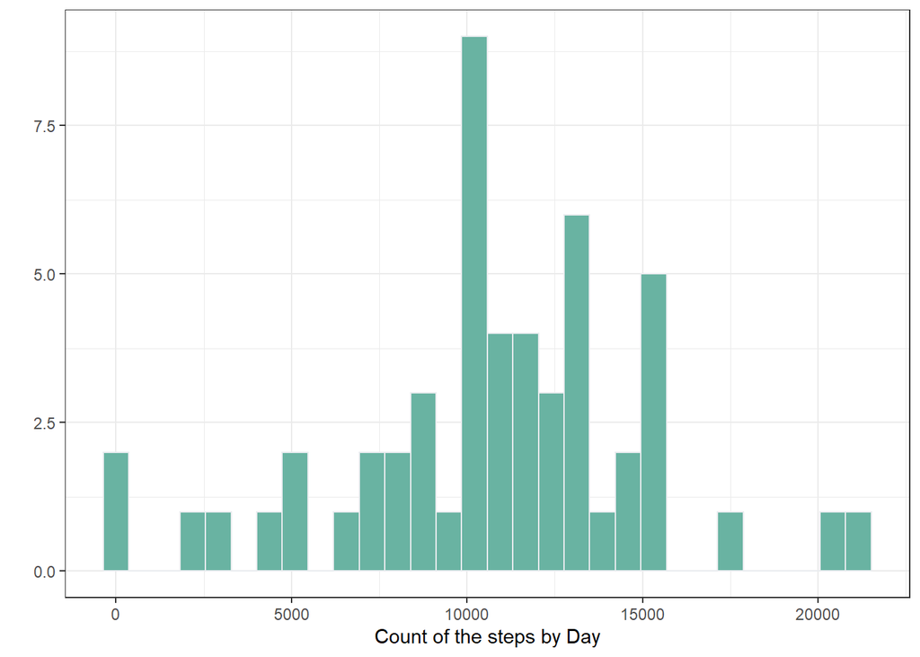

Although based on the graphic it appear the data have not had important changes the task require us calculate the median and mean

```r
summary(data_v2$Day)
```

```
##    Min. 1st Qu.  Median    Mean 3rd Qu.    Max.
##      41    8841   10765   10766   13294   21194
```

```r
summary(complete_data2$Steps)
```

```
##    Min. 1st Qu.  Median    Mean 3rd Qu.    Max.
##      41    8918   10600   10727   12883   21194
```

## 5. Are there differences in activity patterns between weekdays and weekends?

For this part the weekdays() function may be of some help here.

- Create a new factor variable in the dataset with two levels – “weekday” and “weekend” indicating whether a given date is weekday or weekend day.

```r
data_v5 <- complete_data1
data_v5$weekday <- weekdays(data_v5$date)
data_v5$weekday <- gsub("lunes", "weekday", data_v5$weekday)
data_v5$weekday <- gsub("martes", "weekday", data_v5$weekday)
data_v5$weekday <- gsub("miércoles", "weekday", data_v5$weekday)
data_v5$weekday <- gsub("jueves", "weekday", data_v5$weekday)
data_v5$weekday <- gsub("viernes", "weekday", data_v5$weekday)
data_v5$weekday <- gsub("sábado", "weekend", data_v5$weekday)
data_v5$weekday <- gsub("domingo", "weekend", data_v5$weekday)
```

- Make a panel plot containing a time series plot (i.e. type = “l”) of the 5-minute interval (x-axis) and the average number of steps taken, averaged across all weekday days or weekend days (y-axis)

```r
data_v6 <- data_v5 %>% group_by(weekday, interval) %>% summarise(`Average of steps` = mean(steps, na.rm = TRUE))
```

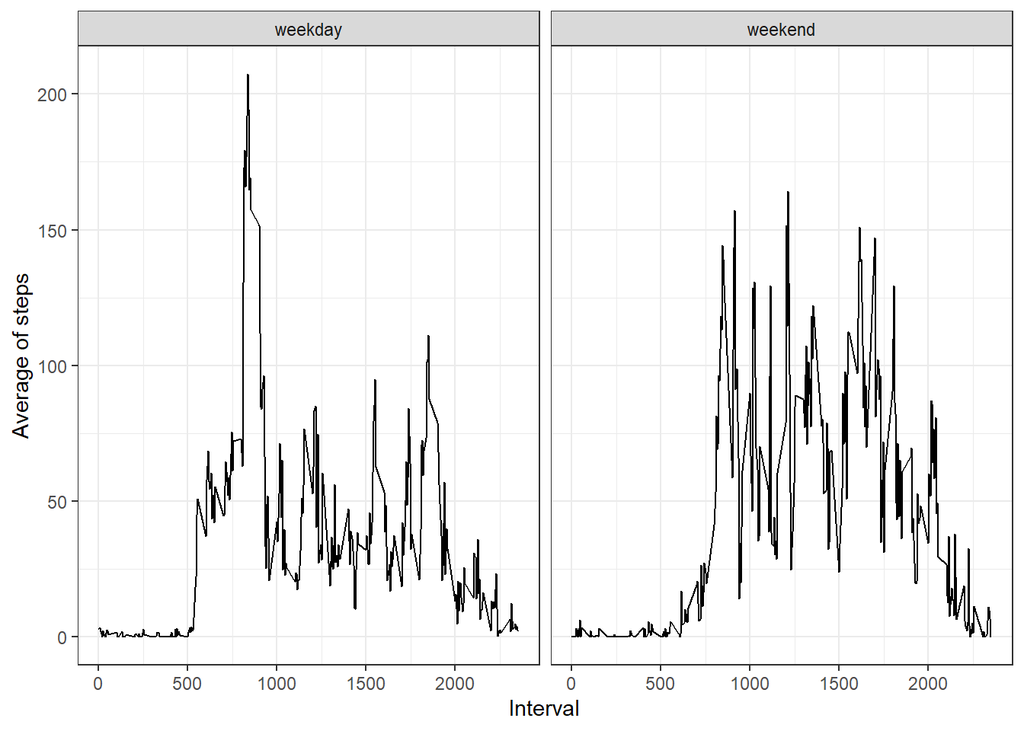

```r
  ggplot(data = data_v6, aes(x = interval, y = `Average of steps`)) + facet_grid(.~weekday) +
    geom_line() + theme_bw() + xlab("Interval")
```